# Yuexin Yu BCB420 Assignment 2

# Where the project was left

Data is from “Histone H3 lysine 4 acetylation-methylation dynamics define breast cancer subtypes [RNA-seq]” whose series number is GSE75168. It can be downloaded from GEO

The GEO description is, as a summary:

_Experiment title__: Histone H3 lysine 4 acetylation-methylation dynamics define breast cancer subtypes [RNA-seq]

**Experiemtn type**: Expression profiling by high throughput sequencing

**Platform title**: Illumina NextSeq 500 (Homo sapiens)

**Submission data**: Feb 10, 2016 analysis. **LAst update data**: Mar 26 2019

**Organisms**: Homo sapiens

**Number of GEO datasets that use this techology**: 177

**Number of GEO samples that use this technology**: 4012

To define the relative roles of histone H3 methylation (H3K4me3) and acetylation (H3K4ac) in breast cancer, genomic regions are determined which are enriched for both marks in normal-like, transformed and metastatic cells. There were 3 human mammary cell lines chosen to represent a normal-like subtype, which is MCF10A, and two cancer subtypes, which are luminal MCF7 and basal-like metastatic MDA-MB-231. They recapitulate the transitional differentiation which is observed in breast cancer subtypes.And an epigenetic signature of distinct stages of cancer is defined and molecular differences leading to phenotypic changes during cancer progression are determined by esatblishing changes in H3K4me3 and H3K4ac in these three model cell lines. The experiment samples the RNA sequence of cell lines MCF10A, MCF7, and MDA-MB-231 with 3 replicates.

Genes in data with low expression (<3 counts) were removed from the analysis.

See more description on https://www.ncbi.nlm.nih.gov/geo/query/acc.cgi?acc=GSE75168.

The data was normalized, cleaned, and the up to date identifers from ensembl were assigned. The data with null identifers were removed from the dataframe.

# Initial setup

```r
if (!requireNamespace("BiocManager", quietly = TRUE))
    install.packages("BiocManager")
if (!requireNamespace("limma", quietly = TRUE))
    BiocManager::install("limma")
if (!requireNamespace("ComplexHeatmap", quietly = TRUE))
  BiocManager::install("ComplexHeatmap")
if (!requireNamespace("circlize", quietly = TRUE))
  BiocManager::install("circlize")
if (!requireNamespace("Biobase", quietly = TRUE))
  BiocManager::install("Biobase")
if (!requireNamespace("edgeR", quietly = TRUE))
  BiocManager::install("edgeR")
```

# differential gene expression

## 0. Load the data with identifiers

```r
normalized_count_data <- read.table(file = file.path(".", "GSE75168_normalized_counts.txt"),
                                    header = TRUE, sep = "\t", stringsAsFactors = FALSE,
                                    check.names = FALSE)
```

Take a look of the data

```r
head(normalized_count_data)
```

```
##   ensembl_gene_id hgnc_symbol MCF10A_R1 MCF10A_R2  MCF10A_R3     MCF7_R1
## 1 ENSG00000000003      TSPAN6 22.200016 34.199112 17.1660040 18.00290233
## 2 ENSG00000000419        DPM1 21.359342 12.367207 21.7109745 63.24521909
## 3 ENSG00000000457       SCYL3 15.505761 12.493403  8.1984276  7.88145494
## 4 ENSG00000000460    C1orf112 10.804215  2.176881 13.0405692 10.84045732
## 5 ENSG00000000971         CFH  1.525667 17.730536  0.8041102  0.02765423
## 6 ENSG00000001036       FUCA2 93.626154 30.823369 68.4018062 66.25952993
##       MCF7_R2    MCF7_R3 MDA-MB-231_R1 MDA-MB-231_R2 MDA-MB-231_R3
## 1 15.03363367 13.8677716     20.910414     19.704343     18.424411
## 2 52.47740393 51.5537551     21.577768     20.371345     22.390777
## 3  8.45892455  8.5469045      8.304845      9.615942      7.523301
## 4 12.74852135 11.8986318     24.098881     22.122224     24.540291
## 5  0.02004484  0.0209483     20.391361     21.427431     21.469556
## 6 65.04552168 64.2274739     58.541744     53.276764     56.475937
```

## 1. Create heatmaps for normalied coount data

Create a numerical matrix that we can create a heatmap from

```r
heatmap_matrix <- normalized_count_data[, 3:ncol(normalized_count_data)]
rownames(heatmap_matrix) <- normalized_count_data$ensembl_gene_id
colnames(heatmap_matrix) <- colnames(normalized_count_data[, 3:ncol(normalized_count_data)])
```

Create a heatmap which transtlates numbers into a colr scale over many sampoles and measurements.

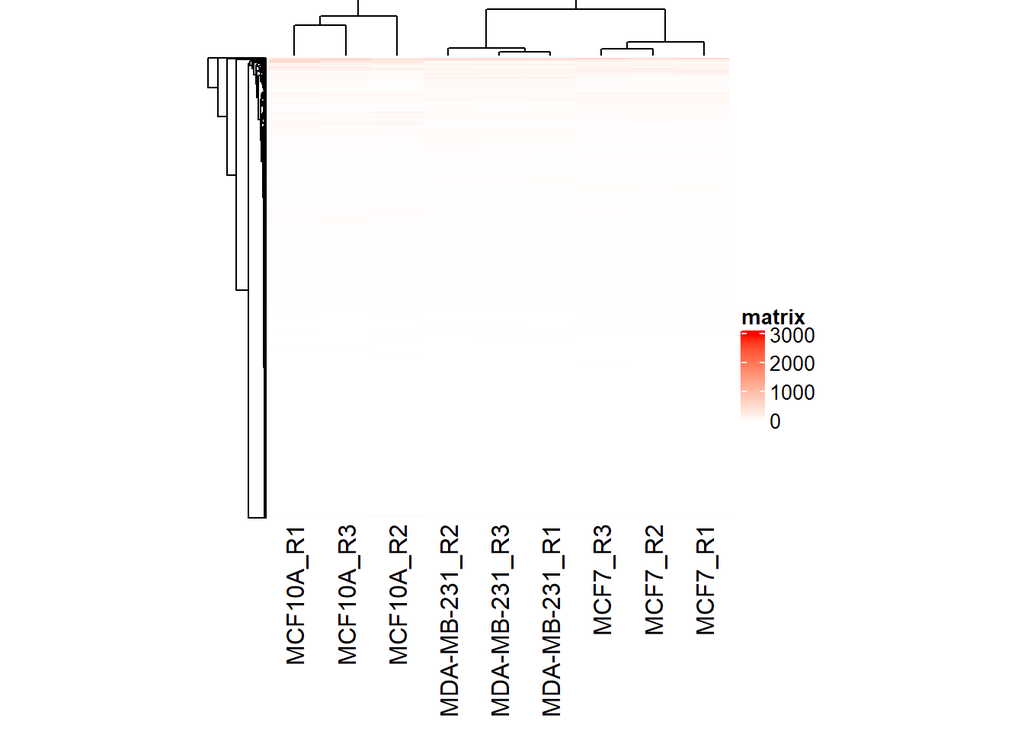

```r
library(ComplexHeatmap)
library(circlize)

if(min(heatmap_matrix) == 0){
  heatmap_col = circlize::colorRamp2(c(0, max(heatmap_matrix)), c("white", "red"))
} else {
  heatmap_col = circlize::colorRamp2(c(min(heatmap_matrix), 0, max(heatmap_matrix)), c("blue", "white", "red"))
}

# It turns out the code runs to the first chunk of the if condition
# which shows that there is at least one 0 in heatmap_matrix

current_heatmap <- ComplexHeatmap::Heatmap(as.matrix(heatmap_matrix),
                                           name = "matrix",
                                           show_row_dend = TRUE,
                                           show_column_dend = TRUE,
                                           col = heatmap_col,
                                           show_column_names = TRUE,
                                           show_row_names = FALSE,
                                           show_heatmap_legend = TRUE,
                                           height = unit(8, "cm"),
                                           width = unit(8, "cm"))

current_heatmap
```

Since the range of the normalized count is large, and most of count are assembled in the lower than 100 range. And the white to red from the low to the high counts color scheme is not visualized friendly. This leads to the overall white heatmap visualization.

Using Row-normalization to generate heatmap

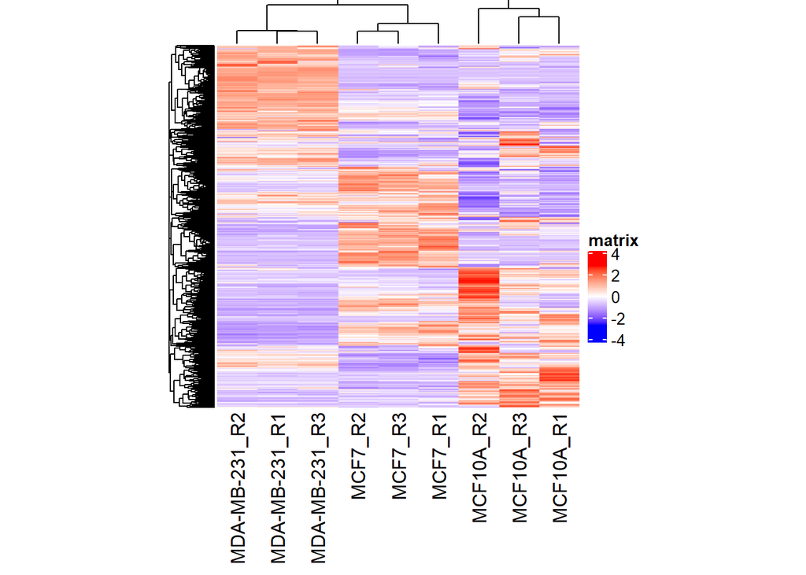

```r
library(ComplexHeatmap)
library(circlize)

heatmap_matrix_r <- t(scale(t(heatmap_matrix)))

if(min(heatmap_matrix_r) == 0){
  heatmap_col_r = circlize::colorRamp2(c(0, max(heatmap_matrix_r)), c("white", "red"))
} else {
  heatmap_col_r = circlize::colorRamp2(c(min(heatmap_matrix_r), 0, max(heatmap_matrix_r)), c("blue", "white", "red"))
}

current_heatmap_r <- ComplexHeatmap::Heatmap(as.matrix(heatmap_matrix_r),
                                             name = "matrix",
                                             show_row_dend = TRUE,
                                             show_column_dend = TRUE,
                                             col = heatmap_col_r,
                                             show_column_names = TRUE,
                                             show_row_names = FALSE,
                                             show_heatmap_legend = TRUE,
                                             height = unit(8, "cm"),
                                             width = unit(8, "cm"))

current_heatmap_r
```

## 2.1 Compare the expression of a single gene

To compare the expression of a single gene. Since *KRT15* has the highest normalized count in MCF10A in the first replication and relatively high in replaication 2 and 3 but pretty low in MDA-MB-231 and MCF7, it is picked to analyse here.

```r
MCF10A_samples <- grep(colnames(normalized_count_data), pattern = "^MCF10A")
MDA_samples <- grep(colnames(normalized_count_data), pattern = "^MDA")
MCF7_samples <- grep(colnames(normalized_count_data), pattern = "^MCF7")

gene_of_interest <- which(normalized_count_data$hgnc_symbol == "KRT15")

KRT15_MCF10A_samples <- t(normalized_count_data[gene_of_interest, MCF10A_samples])
colnames(KRT15_MCF10A_samples) <- c("MCF10A_samples")

KRT15_MDA_samples <- t(normalized_count_data[gene_of_interest, MDA_samples])
colnames(KRT15_MDA_samples) <- c("MDA_samples")

KRT15_MCF7_samples <- t(normalized_count_data[gene_of_interest, MCF7_samples])
colnames(KRT15_MCF7_samples) <- c("MCF7_samples")
```

Null hypothesis of the two smaple t-test is that there is *NO* difference in means of each sample Test if KRT15 differentially expressed in my samples under the condition that both samples in the t.test function are normally distributed.

```r
t.test(x=t(KRT15_MCF10A_samples), y=t(KRT15_MCF7_samples))
```

```
##
##  Welch Two Sample t-test
##
## data:  t(KRT15_MCF10A_samples) and t(KRT15_MCF7_samples)
## t = 7.8035, df = 2, p-value = 0.01603
## alternative hypothesis: true difference in means is not equal to 0
## 95 percent confidence interval:
##  1042.271 3604.250
## sample estimates:
##  mean of x  mean of y
## 2325.14231    1.88202
```

```r
t.test(x=t(KRT15_MCF10A_samples), y=t(KRT15_MDA_samples))
```

```
##
##  Welch Two Sample t-test
##
## data:  t(KRT15_MCF10A_samples) and t(KRT15_MDA_samples)
## t = 7.8047, df = 2, p-value = 0.01602
## alternative hypothesis: true difference in means is not equal to 0
## 95 percent confidence interval:
##  1042.623 3604.603
## sample estimates:
##   mean of x   mean of y
## 2325.142308    1.529188
```

```r
t.test(x=t(KRT15_MCF7_samples), y=t(KRT15_MDA_samples))
```

```
##
##  Welch Two Sample t-test
##
## data:  t(KRT15_MCF7_samples) and t(KRT15_MDA_samples)
## t = 1.3766, df = 3.8663, p-value = 0.243
## alternative hypothesis: true difference in means is not equal to 0
## 95 percent confidence interval:
##  -0.3685985  1.0742630
## sample estimates:
## mean of x mean of y
##  1.882020  1.529188
```

## 2.2 Select model for the differential gene expression analysis for all genes in my dataset

First, generate the MDSPlot to double check the picked factors in my model.

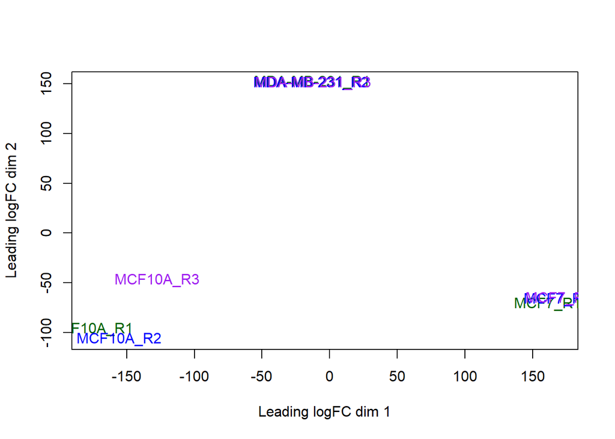

```r
library(limma)

limma::plotMDS(heatmap_matrix, col = rep(c("darkgreen", "blue", "purple"), 10))
```

Since from the MDSPlot, samples are assembled in different cell line subtypes (MCF10A, MCF7, MDA-MB-231). The subtypes can be hypothesized to contribute to the differential, as the analysis in the previous single gene expression analysis.

Hence, my data will grouped based on the subtypes.

```r
# Define the groups
samples <- data.frame(lapply(colnames(normalized_count_data)[3:11],
                             FUN=function(x){unlist(strsplit(x, split = "\\_"))[c(1,2)]}))
colnames(samples) <- colnames(normalized_count_data)[3:11]
rownames(samples) <- c("cell_line_subtype", "replicate")
samples <- data.frame(t(samples),
                      stringsAsFactors=FALSE)
samples
```

```
##               cell_line_subtype replicate
## MCF10A_R1                MCF10A        R1
## MCF10A_R2                MCF10A        R2
## MCF10A_R3                MCF10A        R3
## MCF7_R1                    MCF7        R1
## MCF7_R2                    MCF7        R2
## MCF7_R3                    MCF7        R3
## MDA-MB-231_R1        MDA-MB-231        R1
## MDA-MB-231_R2        MDA-MB-231        R2
## MDA-MB-231_R3        MDA-MB-231        R3
```

### 2.2.1 Limma

Try linear model, which describe a continuous response variable as a function of one or more predictor variables, for my data. First, try empirical Bayes in the limma package.

Note that since the significance of over-representation was determined by Bonferroni correction in the paper of the data [1]. To make it consistent to later process, the **adjust.method** here is **“bonferroni”**.

```r
library(limma)
library(Biobase)

# Create a design matrix
model_design <- model.matrix(~ samples$cell_line_subtype)

# Create data matrix
expressionMatrix <- as.matrix(normalized_count_data[,3:11])
rownames(expressionMatrix) <- normalized_count_data$ensembl_gene_id
colnames(expressionMatrix) <- colnames(normalized_count_data)[3:11]
minimalSet <- Biobase::ExpressionSet(assayData = expressionMatrix)

# Fit the data to the linear model
fit <- limma::lmFit(minimalSet, model_design)

# Apply empirical Bayes to compute differential expression for the model
# Note that the higher level of parameters represents the most likely values.
fit2 <- limma::eBayes(fit, trend = TRUE)

topfit <- topTable(fit2, coef = ncol(model_design),
                   adjust.method = "bonferroni",
                   number = nrow(expressionMatrix))

# merge hgnc names to topgit table
output_hits <- merge(normalized_count_data[, 1:2], topfit,
                     by.y = 0, by.x = 1,
                     all.y = TRUE)

# sort by pvalue
output_hits <- output_hits[order(output_hits$P.Value),]

head(output_hits)
```

```
##       ensembl_gene_id hgnc_symbol      logFC   AveExpr        t      P.Value
## 10005 ENSG00000169515       CCDC8   7.867246  2.629298 61.34139 9.760409e-12
## 13947 ENSG00000213988       ZNF90   4.340300  1.452167 55.22112 2.208824e-11
## 12803 ENSG00000197044      ZNF441   4.484171  1.534904 54.12766 2.580086e-11
## 693   ENSG00000060982       BCAT1 248.392710 83.269091 53.19097 2.954751e-11
## 5488  ENSG00000133131       MORC4  98.425611 39.977454 52.42907 3.305105e-11
## 2866  ENSG00000107554       DNMBP 138.813896 58.345408 52.34022 3.348926e-11
##          adj.P.Val        B
## 10005 1.681328e-07 4.455098
## 13947 3.804921e-07 4.435522
## 12803 4.444457e-07 4.431322
## 693   5.089854e-07 4.427521
## 5488  5.693374e-07 4.424281
## 2866  5.768861e-07 4.423894
```

```r
sprintf("The number of genes in the data: %i",
        as.integer(nrow(normalized_count_data)))
```

```
## [1] "The number of genes in the data: 17226"
```

```r
sprintf("The number of gene passing the threshold p-value < 0.05: %i",
        as.integer(length(which(output_hits$P.Value < 0.05))))
```

```
## [1] "The number of gene passing the threshold p-value < 0.05: 9486"
```

```r
sprintf("The number of genes passing correction: %i",
        as.integer(length(which(output_hits$adj.P.Val < 0.05))))
```

```
## [1] "The number of genes passing correction: 957"
```

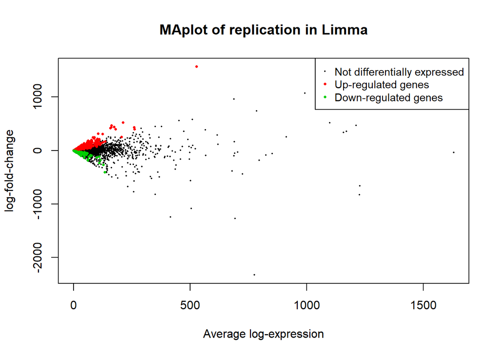

```r
#library(edgeR)
library(limma)

# Create MAPlot
topfit_results <- topfit[rownames(minimalSet),]
topfit_status <- apply(topfit_results, 1, function(gene) {
  if (gene["logFC"] < 0 && gene["adj.P.Val"] < 0.05) {
    return("Down-regulated genes")
  } else if (gene["logFC"] > 0 && gene["adj.P.Val"] < 0.05) {
    return("Up-regulated genes")
  } else {
    return("Not differentially expressed")
  }
})

#qlf_output_hits_status

limma::plotMD(fit2, column = ncol(fit2), status = topfit_status,
              cex = 0.5, main = "MAplot of replication in Limma")
```

As the number of tests performed increases the likelihood that a positive results will occur simply by chance increases, it should be controlled for family-wise error rate or for false discovery rate.

Hence, I try to improve the results if we account for the replicate variability.

The **adjust.method** here is **“bonferroni”** again.

```r
library(limma)

# Create a new design matrix
model_design_rep <- model.matrix(~ samples$replicate + samples$cell_line_subtype)

# Fit the data to the model
fit_rep <- limma::lmFit(minimalSet, model_design_rep)

# Apply empirical Bayes to compute differential expression for the model
# Note that the higher level of parameters represents the most likely values.
fit2_rep <- limma::eBayes(fit_rep, trend = TRUE)

topfit_rep <- topTable(fit2_rep, coef = ncol(model_design_rep),
                   adjust.method = "bonferroni",
                   number = nrow(expressionMatrix))

# merge hgnc names to topgit table
output_hits_rep <- merge(normalized_count_data[, 1:2], topfit_rep,
                     by.y = 0, by.x = 1,
                     all.y = TRUE)

# sort by pvalue
output_hits_rep <- output_hits_rep[order(output_hits_rep$P.Value),]

head(output_hits_rep)
```

```
##       ensembl_gene_id hgnc_symbol      logFC   AveExpr        t      P.Value
## 10005 ENSG00000169515       CCDC8   7.867246  2.629298 52.18269 5.001569e-09
## 693   ENSG00000060982       BCAT1 248.392710 83.269091 50.51005 6.048568e-09
## 13947 ENSG00000213988       ZNF90   4.340300  1.452167 47.89130 8.251299e-09
## 7921  ENSG00000154553      PDLIM3   5.765326  1.939157 47.69800 8.448254e-09
## 2866  ENSG00000107554       DNMBP 138.813896 58.345408 47.05902 9.139624e-09
## 12803 ENSG00000197044      ZNF441   4.484171  1.534904 46.86205 9.365952e-09
##          adj.P.Val        B
## 10005 8.615703e-05 2.255913
## 693   1.041926e-04 2.251247
## 13947 1.421369e-04 2.242956
## 7921  1.455296e-04 2.242291
## 2866  1.574392e-04 2.240033
## 12803 1.613379e-04 2.239318
```

```r
sprintf("The number of genes in the data: %i",
        as.integer(nrow(normalized_count_data)))
```

```
## [1] "The number of genes in the data: 17226"
```

```r
sprintf("The number of gene passing the threshold p-value < 0.05: %i",
        as.integer(length(which(output_hits_rep$P.Value < 0.05 ))))
```

```
## [1] "The number of gene passing the threshold p-value < 0.05: 9341"
```

```r
sprintf("The number of genes passing correction: %i",
        as.integer(length(which(output_hits_rep$adj.P.Val < 0.05 ))))
```

```
## [1] "The number of genes passing correction: 465"
```

The thresholds of p-value for both models are set as 0.05 to adjust the p-values to account for the fact that each time there is a 5% chance my finding is obtained by chance.

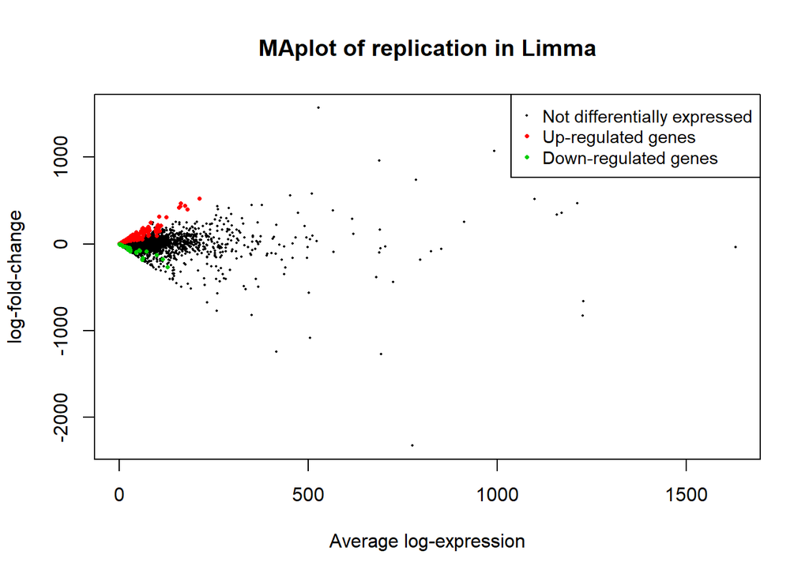

```r
#library(edgeR)
library(limma)

# Create MAPlot
topfit_rep_results <- topfit_rep[rownames(minimalSet),]
topfit_rep_status <- apply(topfit_rep_results, 1, function(gene) {
  if (gene["logFC"] < 0 && gene["adj.P.Val"] < 0.05) {
    return("Down-regulated genes")
  } else if (gene["logFC"] > 0 && gene["adj.P.Val"] < 0.05) {
    return("Up-regulated genes")
  } else {
    return("Not differentially expressed")
  }
})

limma::plotMD(fit2_rep, column = ncol(fit2_rep), status = topfit_rep_status,
              cex = 0.5,
              main = "MAplot of replication in Limma")
```

Compare the results from these two models by plot. Note that all p-values are initialized as *black*. All p-value in the first model passing the threshold p-vale < 0.05 is colored in *orange*, and the ones in the second model is colored in *blue*. The genes passing both models are colored in *red*.

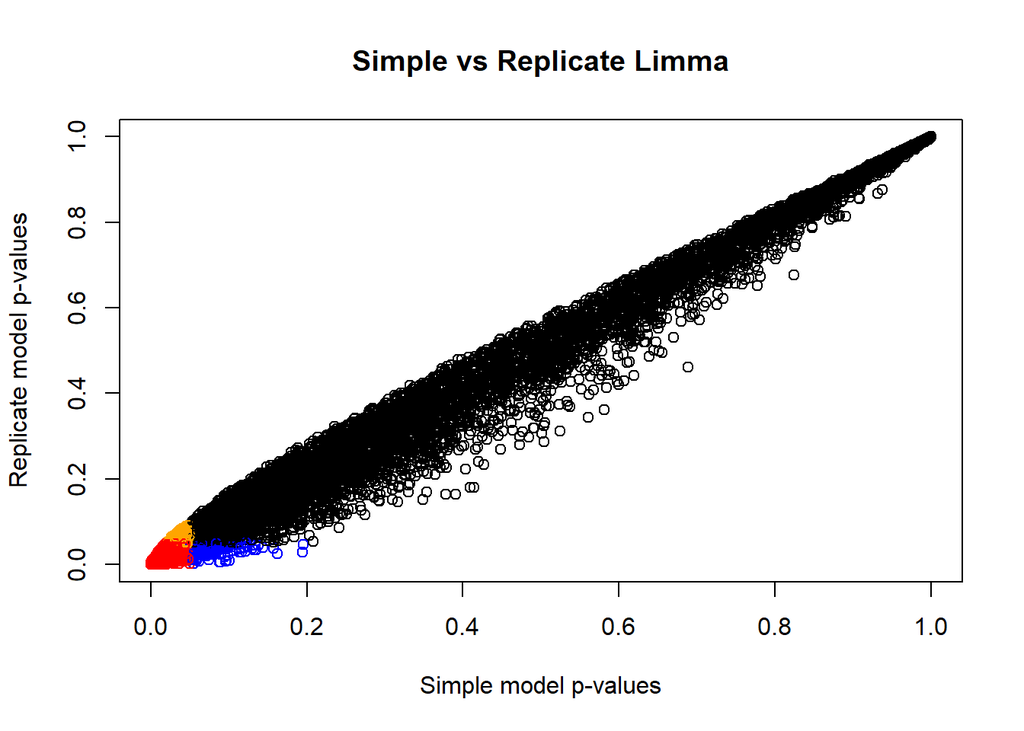

```r
simple_model_pvalues <- data.frame(ensembl_id = output_hits$ensembl_gene_id,
                                   simple_pvalue = output_hits$P.Value)
rep_model_pvalues <- data.frame(ensembl_id = output_hits_rep$ensembl_gene_id,
                                replicate_pvalue = output_hits_rep$P.Value)

two_models_pvalues <- merge(simple_model_pvalues,
                            rep_model_pvalues,
                            by.x = 1, by.y = 1)

# Color each genes by its p-value, as well as checking if the number of each color matches to the number of genes passing threshold in different models (in comments so will not run directly)
two_models_pvalues$color <- "black"
#length(which(two_models_pvalues$color == "black")) == nrow(two_models_pvalues)

two_models_pvalues$color[which(two_models_pvalues$simple_pvalue < 0.05)] <- "orange"
#length(which(two_models_pvalues$color == "orange")) == length(which(simple_model_pvalues$simple_pvalue < 0.05))

two_models_pvalues$color[which(two_models_pvalues$replicate_pvalue < 0.05)] <- "blue"
#length(which(two_models_pvalues$color == "blue")) == length(which(rep_model_pvalues$replicate_pvalue < 0.05))

two_models_pvalues$color[which(two_models_pvalues$simple_pvalue < 0.05 & two_models_pvalues$replicate_pvalue < 0.05)] <-"red"
#length(which(two_models_pvalues$color == "red")) == length(which(two_models_pvalues$simple_pvalue < 0.05 & two_models_pvalues$replicate_pvalue < 0.05))

#length(which(two_models_pvalues$color != "black")) == length(which(two_models_pvalues$simple_pvalue < 0.05 | two_models_pvalues$replicate_pvalue < 0.05 | (two_models_pvalues$simple_pvalue < 0.05 & two_models_pvalues$replicate_pvalue < 0.05)))

#length(which(two_models_pvalues$color != "black"))/nrow(two_models_pvalues)

# MAPlot
plot(two_models_pvalues$simple_pvalue, two_models_pvalues$replicate_pvalue,
     col = two_models_pvalues$color,
     xlab = "Simple model p-values",
     ylab = "Replicate model p-values",
     main = "Simple vs Replicate Limma")
```

Highlight the gene of interest in MAPlot in *red* and the rest turns in *grey*.

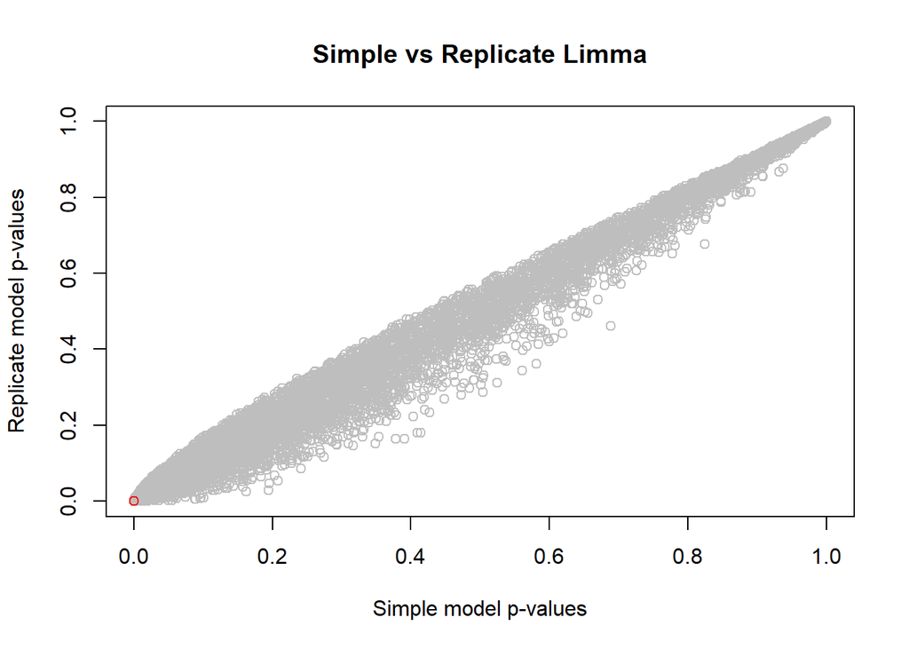

```r
ensembl_of_interest <- normalized_count_data$ensembl_gene_id[which(normalized_count_data$hgnc_symbol == "KRT15")]

two_models_pvalues$color <- "grey"
two_models_pvalues$color[which(two_models_pvalues$ensembl_id == ensembl_of_interest)] <- "red"

# Plot in MAPlot
plot(two_models_pvalues$simple_pvalue, two_models_pvalues$replicate_pvalue,
     col = two_models_pvalues$color,
     xlab = "Simple model p-values",
     ylab = "Replicate model p-values",
     main = "Simple vs Replicate Limma")

# Since the gene of interest color is blocked in the plot, add it after generating the plot manually.
points(two_models_pvalues$simple_pvalue[two_models_pvalues$color == "red"],
       two_models_pvalues$replicate_pvalue[two_models_pvalues$color == "red"],
       col = "red")
```

It turns that the p-value of the gene of interest, KRT15, passed the threshold of p-value for both of models.

### 2.2.2 EdgeR

Model will be used here is glmQLFTest, which estimates the quasi-likelihood (QL) that is used for more complicated models and is highly recommended for bulk RNASeq expreiments. The threshold of p-value here will still be smaller than 0.05 to unified filter of the results to previous model results.

```r
library(edgeR)

# set up edgeR pbjects
data_matrix <- as.matrix(normalized_count_data[, 3:11])
rownames(data_matrix) <- normalized_count_data$ensembl_gene_id
d = edgeR::DGEList(counts = data_matrix, group = samples$cell_line_subtype)

# estimate dispersion
d <- edgeR::estimateDisp(d, model_design)

# Fit the model
fit <- glmQLFit(d, model_design)

# calculate differential expression using the Quasi likelihood model
qlf.cell_line_sub <- edgeR::glmQLFTest(fit, coef = 'samples$cell_line_subtypeMDA-MB-231')

# Get all results
qlf_output_hits <- edgeR::topTags(qlf.cell_line_sub, sort.by = "PValue",
                                  n = nrow(normalized_count_data))

sprintf("The number of genes: %i",
        nrow(qlf.cell_line_sub))
```

```
## [1] "The number of genes: 17226"
```

```r
sprintf("The number of genes passing the threshold p-value < 0.05: %i",
        length(which(qlf_output_hits$table$PValue < 0.05)))
```

```
## [1] "The number of genes passing the threshold p-value < 0.05: 6876"
```

```r
sprintf("The number of genes passing correction: %i",
        length(which(qlf_output_hits$table$FDR < 0.05)))
```

```
## [1] "The number of genes passing correction: 5462"
```

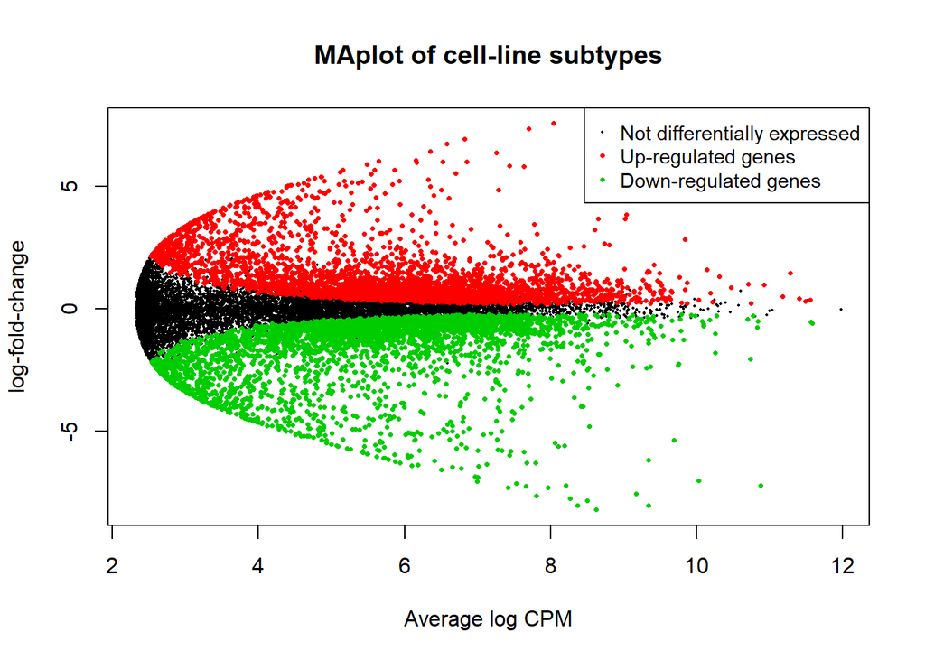

```r
# MAPlot
#library(edgeR)
library(limma)

qlf_results <- qlf.cell_line_sub[rownames(minimalSet),]

qlf_status <- apply(qlf_results$table, 1, function(gene) {
  if (gene["logFC"] < 0 && gene["PValue"] < 0.05) {
    return("Down-regulated genes")
  } else if (gene["logFC"] > 0 && gene["PValue"] < 0.05) {
    return("Up-regulated genes")
  } else {
    return("Not differentially expressed")
  }
})

#qlf_output_hits_status
limma::plotMD(fit, column = ncol(fit), status = qlf_status,
              cex = 0.5,
              main = "MAplot of cell-line subtypes")
```

Compare the result of this model to the result of cell line subtype model, which are the comparison of limma and quasi likelihood.

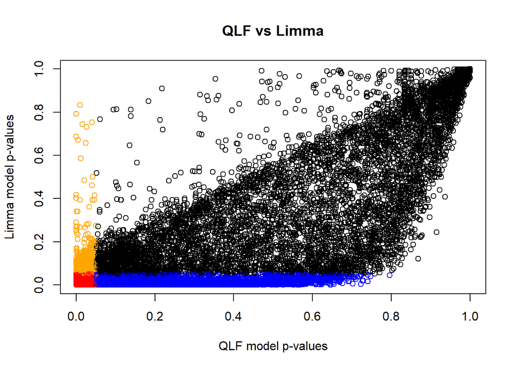

```r
qlf_model_pvalues <- data.frame(ensembl_id = rownames(qlf_output_hits),
                                qlf_pvalues = qlf_output_hits$table$PValue)

limma_model_pvalues<- data.frame(ensembl_id = output_hits$ensembl_gene_id,
                                 limma_pvalues = output_hits$P.Value)

two_models_pvalues_lq <- merge(qlf_model_pvalues, limma_model_pvalues,
                            by.x = 1, by.y = 1)

#qlf_model_pvalues
#limma_model_pvalues
#two_models_pvalues

two_models_pvalues_lq$color <- "black"
two_models_pvalues_lq$color[which(two_models_pvalues_lq$qlf_pvalues < 0.05)] <- "orange"
two_models_pvalues_lq$color[which(two_models_pvalues_lq$limma_pvalues < 0.05)] <- "blue"
two_models_pvalues_lq$color[which(two_models_pvalues_lq$qlf_pvalues < 0.05 & two_models_pvalues_lq$limma_pvalues < 0.05)] <- "red"

#length(which(two_models_pvalues$qlf_pvalues < 0.05 & two_models_pvalues$limma_pvalues < 0.05))

# Plot
plot(two_models_pvalues_lq$qlf_pvalues, two_models_pvalues_lq$limma_pvalues,
     col = two_models_pvalues_lq$color,
     xlab = "QLF model p-values", ylab = "Limma model p-values",
     main = "QLF vs Limma")
```

It shows that most of p-values for each gene in two models are divergent.

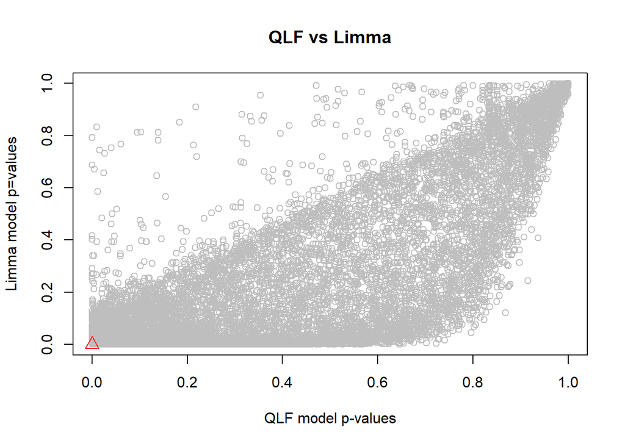

```r
ensembl_of_interest <- normalized_count_data$ensembl_gene_id[which(normalized_count_data$hgnc_symbol == "KRT15")]

two_models_pvalues_lq$color <- "grey"
two_models_pvalues_lq$color[two_models_pvalues_lq$ensembl_id == ensembl_of_interest] <- "red"

# MAPlot
plot(two_models_pvalues_lq$qlf_pvalues, two_models_pvalues_lq$limma_pvalues,
     col = two_models_pvalues_lq$color,
     xlab = "QLF model p-values",
     ylab = "Limma model p=values",
     main = "QLF vs Limma")

points(two_models_pvalues[two_models_pvalues_lq$ensembl_id == ensembl_of_interest, 2:3],
       pch = 24, col = "red", cex = 1.5)
```

## 2.3. Visualize the top hits accounting for cell line subtypes variability whose p-value < 0.05 using a heatmap

### 2.3.1 Heatmap for limma models

For limma model, by the comparison of the number of gene passing the threshold of p-value < 0.05 in cell-line subtypes model and replicate model above, the model for cell-line sutypes is used.

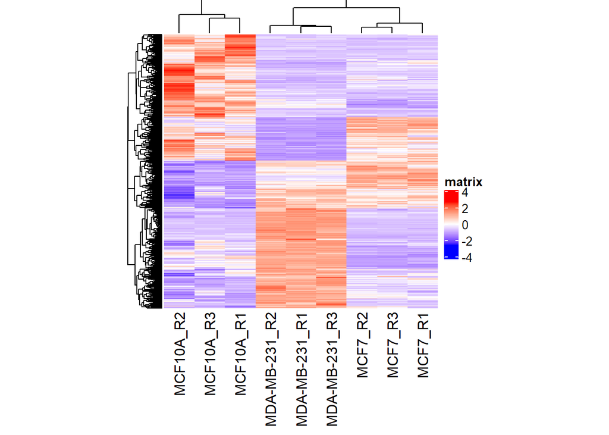

```r
library(ComplexHeatmap)
library(circlize)

top_hits <- output_hits$ensembl_gene_id[output_hits$P.Value < 0.05]
heatmap_matrix_tophits <- t(scale(t(heatmap_matrix[which(rownames(heatmap_matrix) %in% top_hits),])))
#head(heatmap_matrix_tophits)

if(min(heatmap_matrix_tophits) == 0){
  heatmap_col_th = circlize::colorRamp2(c(0, max(heatmap_matrix_tophits)), c("white", "red"))
} else {
  heatmap_col_th = circlize::colorRamp2(c(min(heatmap_matrix_tophits), 0, max(heatmap_matrix_tophits)), c("blue", "white", "red"))
}

current_heatmap <- ComplexHeatmap::Heatmap(as.matrix(heatmap_matrix_tophits),
                                           name = "matrix",
                                           cluster_rows = TRUE,
                                           cluster_columns = TRUE,
                                           show_row_dend = TRUE,
                                           show_column_dend = TRUE,
                                           col = heatmap_col_th,
                                           show_column_names = TRUE,
                                           show_row_names = FALSE,
                                           show_heatmap_legend = TRUE,
                                           height = unit(8, "cm"),
                                           width = unit(8, "cm"))

current_heatmap
```

Sort the columns by replication times

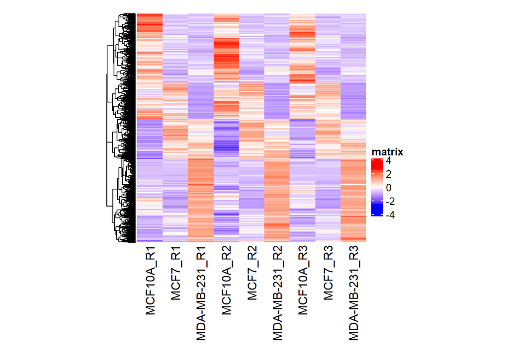

```r
library(ComplexHeatmap)
library(circlize)

heatmap_matrix_tophits <- heatmap_matrix_tophits[, c(grep(colnames(heatmap_matrix_tophits),
                                                          pattern = "\\R1"),
                                                     grep(colnames(heatmap_matrix_tophits),
                                                          pattern = "\\R2"),
                                                     grep(colnames(heatmap_matrix_tophits),
                                                          pattern = "\\R3"))]
#head(heatmap_matrix_tophits)

if(min(heatmap_matrix_tophits) == 0){
  heatmap_col_th = circlize::colorRamp2(c(0, max(heatmap_matrix_tophits)), c("white", "red"))
} else {
  heatmap_col_th = circlize::colorRamp2(c(min(heatmap_matrix_tophits), 0, max(heatmap_matrix_tophits)), c("blue", "white", "red"))
}

current_heatmap <- ComplexHeatmap::Heatmap(as.matrix(heatmap_matrix_tophits),
                                           name = "matrix",
                                           cluster_rows = TRUE,
                                           cluster_columns = FALSE,
                                           show_row_dend = TRUE,
                                           show_column_dend = TRUE,
                                           col = heatmap_col_th,
                                           show_column_names = TRUE,
                                           show_row_names = FALSE,
                                           show_heatmap_legend = TRUE,
                                           height = unit(8, "cm"),
                                           width = unit(8, "cm"))

current_heatmap
```

Try to lower the threshold of p-value to 0.01 to get a slightly cleaner map.

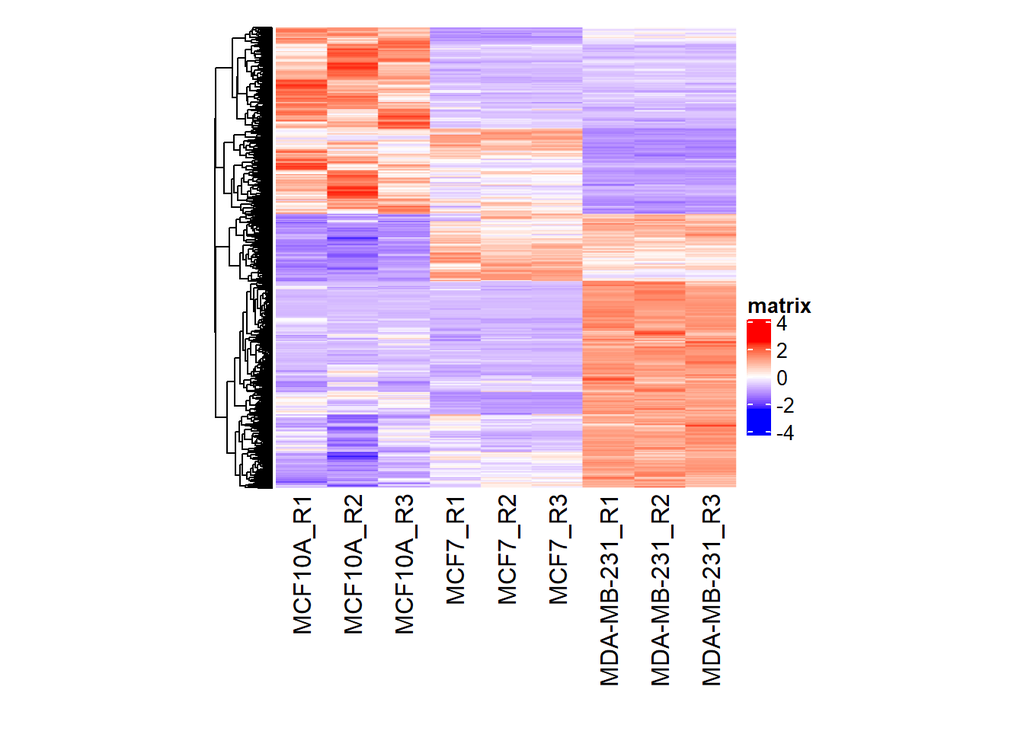

```r
library(ComplexHeatmap)
library(circlize)

top_hits <- output_hits$ensembl_gene_id[output_hits$P.Value < 0.01]
heatmap_matrix_tophits <- t(scale(t(heatmap_matrix[which(rownames(heatmap_matrix) %in% top_hits),])))
#head(heatmap_matrix_tophits)

#heatmap_matrix_tophits <- heatmap_matrix_tophits[, c(grep(colnames(heatmap_matrix_tophits),
#                                                          pattern = "\\R1"),
#                                                     grep(colnames(heatmap_matrix_tophits),
#                                                          pattern = "\\R2"),
#                                                     grep(colnames(heatmap_matrix_tophits),
#                                                          pattern = "\\R3"))]

if(min(heatmap_matrix_tophits) == 0){
  heatmap_col_th = circlize::colorRamp2(c(0, max(heatmap_matrix_tophits)), c("white", "red"))
} else {
  heatmap_col_th = circlize::colorRamp2(c(min(heatmap_matrix_tophits), 0, max(heatmap_matrix_tophits)), c("blue", "white", "red"))
}

current_heatmap <- ComplexHeatmap::Heatmap(as.matrix(heatmap_matrix_tophits),
                                           name = "matrix",
                                           cluster_rows = TRUE,
                                           cluster_columns = FALSE,
                                           show_row_dend = TRUE,
                                           show_column_dend = FALSE,
                                           col = heatmap_col_th,
                                           show_column_names = TRUE,
                                           show_row_names = FALSE,
                                           show_heatmap_legend = TRUE,
                                           height = unit(8, "cm"),
                                           width = unit(8, "cm"))

current_heatmap
```

### 2.3.2 Heatmap for edgeR model

For quasi model, the model for cell-line sutypes is used.

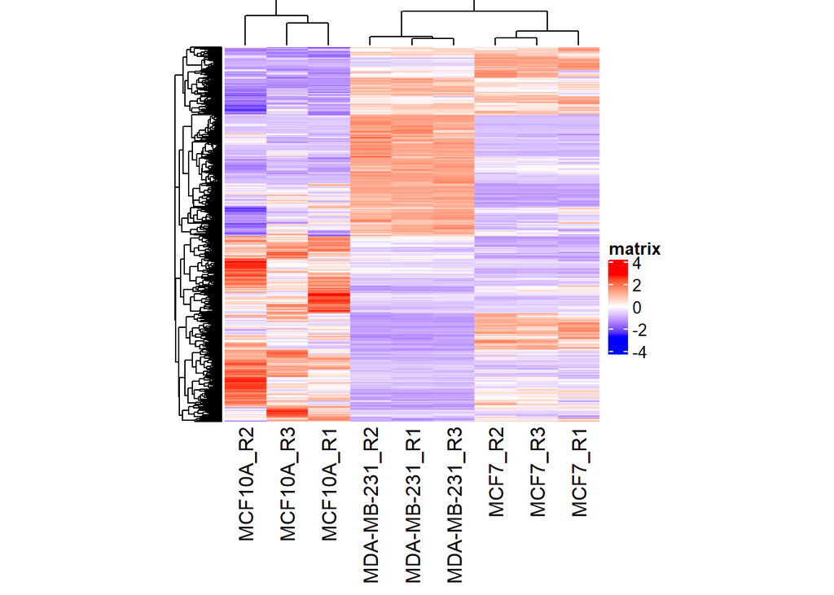

```r
library(ComplexHeatmap)
library(circlize)

top_hits <- rownames(qlf_output_hits$table)[output_hits$P.Value < 0.05]
heatmap_matrix_tophits <- t(scale(t(heatmap_matrix[which(rownames(heatmap_matrix) %in% top_hits),])))

if(min(heatmap_matrix_tophits) == 0){
  heatmap_col_th = circlize::colorRamp2(c(0, max(heatmap_matrix_tophits)), c("white", "red"))
} else {
  heatmap_col_th = circlize::colorRamp2(c(min(heatmap_matrix_tophits), 0, max(heatmap_matrix_tophits)),
                                        c("blue", "white", "red"))
}

current_heatmap <- ComplexHeatmap::Heatmap(as.matrix(heatmap_matrix_tophits),
                                           name = "matrix",
                                           cluster_rows = TRUE,
                                           cluster_columns = TRUE,
                                           show_row_dend = TRUE,
                                           show_column_dend = TRUE,
                                           col = heatmap_col_th,
                                           show_column_names = TRUE,
                                           show_row_names = FALSE,
                                           show_heatmap_legend = TRUE,
                                           height = unit(8, "cm"),
                                           width = unit(8, "cm"))

current_heatmap
```

[figure not shown]

```r
library(ComplexHeatmap)
library(circlize)

top_hits <- rownames(qlf_output_hits$table)[output_hits$P.Value < 0.05]
heatmap_matrix_tophits <- t(scale(t(heatmap_matrix[which(rownames(heatmap_matrix) %in% top_hits),])))
heatmap_matrix_tophits<- heatmap_matrix_tophits[,c(grep(colnames(heatmap_matrix_tophits),
                                                        pattern = "\\R1"),
                                                   grep(colnames(heatmap_matrix_tophits),
                                                        pattern = "\\R2"),
                                                   grep(colnames(heatmap_matrix_tophits),
                                                        pattern = "\\R3"))]

if(min(heatmap_matrix_tophits) == 0){
  heatmap_col_th = circlize::colorRamp2(c(0, max(heatmap_matrix_tophits)),
                                        c( "white", "red"))
} else {
  heatmap_col_th = circlize::colorRamp2(c(min(heatmap_matrix_tophits), 0, max(heatmap_matrix_tophits)),
                                        c("blue", "white", "red"))
}

current_heatmap <- ComplexHeatmap::Heatmap(as.matrix(heatmap_matrix_tophits),
                                           name = "matrix",
                                           cluster_rows = TRUE,
                                           cluster_columns = FALSE,
                                           show_row_dend = TRUE,
                                           show_column_dend = FLASE,
                                           col = heatmap_col_th,
                                           show_column_names = TRUE,
                                           show_row_names = FALSE,
                                           show_heatmap_legend = TRUE,
                                           height = unit(8, "cm"),
                                           width = unit(8, "cm"))

current_heatmap
```

# thresholded over-representation analysis

## Choose method

By the results of different models in differential genes expression, it demonstrates that using *cell line* subtype as factor is better than using replication times *in Bonferroni method in Limma*.The number of genes passing the threshold of p-value < 0.05 in *Quasi likelihood* is much smaller than the ones *in Bonferroni method in Limma*, though the numbers of genes passing the correction approaches to the number of genes passing the threshold 0.05 in *Quasi likelihood*. In addition, the heatmap of *Limma model* is much cleaner than the one of *Quasi likelihood* which is especially revealled in the group of the subtype MCF7. Therefore, the following will use *Bonferroni method in Limma* to perform pathway enrichment analysis.

## Check the number of up-regulated and down-regulated genes

```r
sprintf("The number of gene passing the threshold p-value < 0.05: %i",
        as.integer(length(which(output_hits$P.Value < 0.05))))
```

```
## [1] "The number of gene passing the threshold p-value < 0.05: 9486"
```

```r
sprintf("The number of genes which are up regulated: %i",
        as.integer(length(which(output_hits$P.Value < 0.05 & output_hits$logFC > 0))))
```

```
## [1] "The number of genes which are up regulated: 5117"
```

```r
sprintf("The number of genes which are down regulated: %i",
        as.integer(length(which(output_hits$P.Value < 0.05 & output_hits$logFC < 0))))
```

```
## [1] "The number of genes which are down regulated: 4369"
```

## Create threshold lists of genes and save them into local

```r
output_hits_withgn <- output_hits

output_hits_withgn[, "rank"] <- -log(output_hits_withgn$P.Value, base = 10) * sign(output_hits_withgn$logFC)
output_hits_withgn <- output_hits_withgn[order(output_hits_withgn$rank),]

upregulated_genes <- output_hits_withgn$hgnc_symbol[which(output_hits_withgn$P.Value < 0.05 & output_hits_withgn$logFC > 0)]
downregulated_genes <- output_hits_withgn$hgnc_symbol[which(output_hits_withgn$P.Value < 0.05 & output_hits_withgn$logFC < 0)]

write.table(x = upregulated_genes,
            file = file.path(".", "upregulated_genes.txt"),
            sep = "\t", quote = FALSE,
            row.names = FALSE, col.names = FALSE)
write.table(x = downregulated_genes,
            file = file.path(".", "downregulated_genes.txt"),
            sep = "\t", quote = FALSE,
            row.names = FALSE, col.names = FALSE)

write.table(x = data.frame(genename = output_hits_withgn$hgnc_symbol,
                           F_stat = output_hits_withgn$rank),
            file = file.path(".", "ranked_genelist.txt"),
            sep = "\t", quote = FALSE,
            row.names = FALSE, col.names = FALSE)
```

Thresholded list is easy to use and access; its results are quick and fast; and there are many online tools for it, though many weak signals which can contribute to the whole are ignored and theresults depends on the threshold. Three list files are generated here, **upregulated_genes.txt** and **downregulated_genes.txt** are thresholded lists, which can be accessed over-representation using *g:profiler* later.

## Over-representation analysis

*g:profiler* (https://biit.cs.ut.ee/gprofiler/gost) will be used as the over-representation analysis tools. It is a web server constructed by Reimand et.al from 2007. In g:profiler, up regulated genes thresholded list and down regulated genes thresholded list are used as the query respectively. The organisms is chosen as **Homo sapiens**. In advanced options, Bonferroni correction is set as the significance threshold for the same reason in setting “bonferroni” as the adjust method in Limma, and the threshold is set as 4.9x10^(-9) since according to the paper[1], significance of over-representation was determined with a p-value threshold of 4.9x10^(-9) after Bonferroni correction. In Data sources, the following annotations are selected: *GO biological process*: latest releases on 7.1.2019 *Reactome*: ensembl classes; latest releases on 10.2.2019 *WikiPathways*: latest releases on 9.10.2019

Select the Ensembl ID with the most GO annotations for all genes with multiple Ensembl IDs.

For up-regulated genes:

*Figure 1.* The screenshot of top 20 GO biological process (GO:BP) terms with their statistical values in up-regulated genes

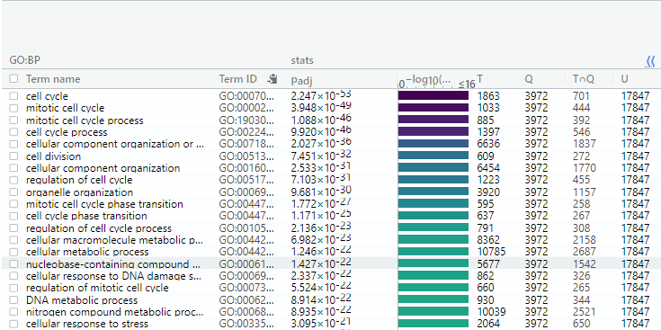

There are 85 terms returned in GO:BP under the threshold 4.9x10^(-9).

*Figure 2.* The screenshot of all Reactome (REAC) terms with their statistical values in up-regulated genes

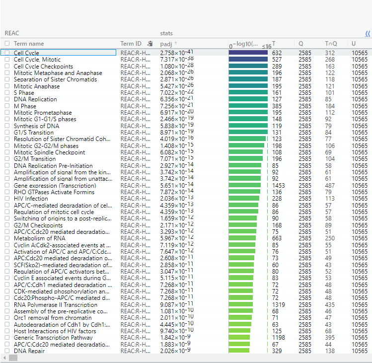

There are 46 terms returned in REAC under the threshold 4.9x10^(-9)

*Figure 3.* The screenshot of all WikiPathways (WP) terms with their statistical values in up-regulated genes

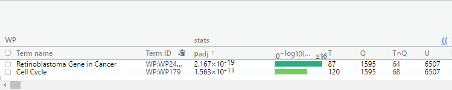

There are 2 terms returned in WP under the threshold 4.9x10^(-9)

Overall, the up-regulated genes were enriched for 85 GO:BC terms, 46 Reactome terms, and 2 WikiPathways terms.

For down-regulated genes:

*Figure 4.* The screenshot of all GO biological process (GO:BP) terms with their statistical values in down-regulated genes

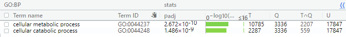

There are 2 terms returned in GO:BP under the threshold 4.9x10^(-9).

Overall, the down-regulated genes were enriched for only 2 GO:BC. And there is no enriched genes from Reactome and WikiPathways data sources.

For all differentialy expressed genes:

*Figure 5.* The screenshot of top 20 GO biological process (GO:BP) terms with their statistical values in all differentially expressed genes

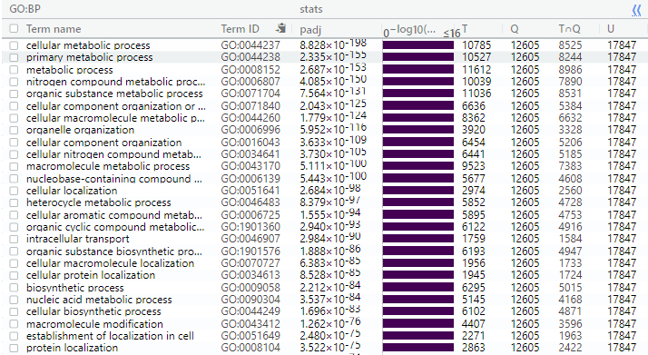

There are 361 terms returned in GO:BP under the threshold 4.9x10^(-9).

*Figure 6.* The screenshot of all Reactome (REAC) terms with their statistical values in all differentially expressed genes

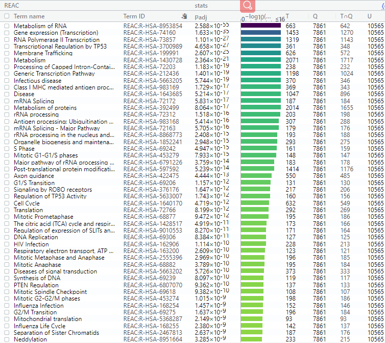

There are 47 terms returned in REAC under the threshold 4.9x10^(-9).

*Figure 7.* The screenshot of all WikiPathways (WP) terms with their statistical values in all differentially expressed genes

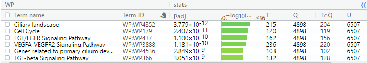

There are 6 terms returned in WP under the threshold 4.9x10^(-9).

Overall, all differentially expressed genes were enriched for 361 GO biological process terms, 47 Reactome terms, and 6 WikiPathways terms.

As a whole, since the non of number of significant enriched terms, which are defined under the threshold of p-value < 4.9*10^(-9), in all data sources is too many (e.g. over 1000). Therefore, there is no need to further restrcit the returned genesets.

These results are consistent to the results in paper[1]. In paper, top 2% from the ranked list of differentially expressed genes are subjected to GO analysis, and GO terms were related to regulation of metabolic process, and cellular macromolecular metabolic process, etc. My observation in Reactome and WikiPathways data source also support their results. The results are also consistent to the paper reviewing molecular subtypes of breast cancer [2]. The paper demonstrates that one of the molecular subtype of triple negative breast cancer (TNBC), basal-like 1 (BL1), usually have high Ki67 proliferative indices while their expression profile is enriched in genes associated with basal cytokeratin gene, cell cycle, and DNA damage response pathways.And my results also show that my genes are enriched in geneset cell cycle. Thus, my results are supported.

# Reference

[1] Messier TL, Gordon JA, Boyd JR, Tye CE et al. Histone H3 lysine 4 acetylation and methylation dynamics define breast cancer subtypes. Oncotarget 2016 Feb 2;7(5):5094-109. PMID: 26783963

[2] Fragomeni SM, Sciallis A, Jeruss JS. Molecular subtypes and local-regional control of breast cancer. Surg Oncol Clin A Am 2018 Jan; 27(1): 95-120. PMID: 29132568